# Heart Disease Challenge

1. Introduction
2. Load Basic Dependencies
3. Heart Disease dataset Analysis
4. Data Exploration
5. Bivariate Analysis
6. Exploratory Data Analysis (EDA)
7. Explanation. Model Validation
8. Conslution
9. References

### 1. Introduction

In this challange we are going to apply Machine Learning analysus on the Hart Disease dataset.

The dataset is provided by four different sources:

- Hungarian Institute of Cardiology
- University Hospital, Zurich, Switzerland
- University Hospital, Basel, Switzerland
- V.A. Medical Center, Long Beach and Cleveland Clinic Foundation

##### Data Set Information

**[[heart disease dataset]](https://archive.ics.uci.edu/ml/datasets/Heart+Disease)**

This database contains 76 attributes, but all published experiments refer to using a subset of 14 of them. In particular, the Cleveland database is the only one that has been used by ML researchers to this date. The "goal" field refers to the presence of heart disease in the patient. It is integer valued from 0 (no presence) to 4. Experiments with the Cleveland database have concentrated on simply attempting to distinguish presence (values 1,2,3,4) from absence (value 0).

##### Attribute Information

Only 14 attributes used:

1. age: age in years
2. sex: sex (1=male; 0=female)
3. cp: chest pain type

   -- Value 1: typical angina  
   -- Value 2: atypical angina  
   -- Value 3: non-anginal pain  
   -- Value 4: asymptomatic
1. trestbps: resting blood pressure (in mm Hg on admission to the hospital)
2. chol: serum cholestoral in mg/dl
3. fbs: (fasting blood sugar > 120 mg/dl) (1 = true; 0 = false)
4. restecg: resting electrocardiographic results

   -- Value 0: normal  
   -- Value 1: having ST-T wave abnormality (T wave inversions and/or ST elevation or depression of > 0.05 mV)  
   -- Value 2: showing probable or definite left ventricular hypertrophy by Estes' criteria
1. thalach: maximum heart rate achieved
2. exang: exercise induced angina (1 = yes; 0 = no)
3. oldpeak = ST depression induced by exercise relative to rest
4. slope: the slope of the peak exercise ST segment

   -- Value 1: upsloping  
   -- Value 2: flat  
   -- Value 3: downsloping
1. ca: number of major vessels (0-3) coloured by flourosopy
2. thal: 3 = normal; 6 = fixed defect; 7 = reversable defect
3. num: diagnosis of heart disease (angiographic disease status)

   -- Value 0: < 50% diameter narrowing  
   -- Value 1: > 50% diameter narrowing

(in any major vessel: attributes 59 through 68 are vessels)

### Goal

This dataset gives a number of variables along with a target condition of having or not having heart disease. The goal of this alayses is to find the major factors that have an impact over the health of people, because understanding the risks will help to prevent a heart attack.

According to this [source](https://www.heart.org/en/health-topics/heart-attack/understand-your-risks-to-prevent-a-heart-attack), the more risk factors you have, and the greater the degree of each risk factor, the higher your chance of developing coronary heart disease – a common term for the buildup of plaque in the heart’s arteries that could lead to heart attack.

The major factors that can't be changed are: increasing age, male gender and heredity. Note that thalassemia, one of the variables in this dataset, is heredity.

Major factors that can be modified are: Smoking, high cholesterol, high blood pressure, physical inactivity, and being overweight and having diabetes. Other factors include stress, alcohol and poor diet/nutrition.

### 2. Load Basic Dependencies

```python
# Import packages
import numpy as np
import pandas as pd

import math
import random
import seaborn as sns
import matplotlib.pyplot as plt
%matplotlib inline

# Change default style
sns.set_style('whitegrid')
```

```python
# Reading the csv file and basic information
data_origin = pd.read_csv('heart.csv')
```

```python
# The head method operates on a dataframe by displaying a number of rows. The first 5 rows are displayed if no arguments are passed.
data_origin.head()
```

|  | age | sex | cp | trestbps | chol | fbs | restecg | thalach | exang | oldpeak | slope | ca | thal | target |
| --- | --- | --- | --- | --- | --- | --- | --- | --- | --- | --- | --- | --- | --- | --- |
| 0 | 63 | 1 | 3 | 145 | 233 | 1 | 0 | 150 | 0 | 2.3 | 0 | 0 | 1 | 1 |
| 1 | 37 | 1 | 2 | 130 | 250 | 0 | 1 | 187 | 0 | 3.5 | 0 | 0 | 2 | 1 |
| 2 | 41 | 0 | 1 | 130 | 204 | 0 | 0 | 172 | 0 | 1.4 | 2 | 0 | 2 | 1 |
| 3 | 56 | 1 | 1 | 120 | 236 | 0 | 1 | 178 | 0 | 0.8 | 2 | 0 | 2 | 1 |
| 4 | 57 | 0 | 0 | 120 | 354 | 0 | 1 | 163 | 1 | 0.6 | 2 | 0 | 2 | 1 |

```python
data_origin.describe([.05, .95])
```

|  | age | sex | cp | trestbps | chol | fbs | restecg | thalach | exang | oldpeak | slope | ca | thal | target |
| --- | --- | --- | --- | --- | --- | --- | --- | --- | --- | --- | --- | --- | --- | --- |
| count | 303.000000 | 303.000000 | 303.000000 | 303.000000 | 303.000000 | 303.000000 | 303.000000 | 303.000000 | 303.000000 | 303.000000 | 303.000000 | 303.000000 | 303.000000 | 303.000000 |
| mean | 54.366337 | 0.683168 | 0.966997 | 131.623762 | 246.264026 | 0.148515 | 0.528053 | 149.646865 | 0.326733 | 1.039604 | 1.399340 | 0.729373 | 2.313531 | 0.544554 |
| std | 9.082101 | 0.466011 | 1.032052 | 17.538143 | 51.830751 | 0.356198 | 0.525860 | 22.905161 | 0.469794 | 1.161075 | 0.616226 | 1.022606 | 0.612277 | 0.498835 |
| min | 29.000000 | 0.000000 | 0.000000 | 94.000000 | 126.000000 | 0.000000 | 0.000000 | 71.000000 | 0.000000 | 0.000000 | 0.000000 | 0.000000 | 0.000000 | 0.000000 |
| 5% | 39.100000 | 0.000000 | 0.000000 | 108.000000 | 175.000000 | 0.000000 | 0.000000 | 108.100000 | 0.000000 | 0.000000 | 0.000000 | 0.000000 | 1.000000 | 0.000000 |
| 50% | 55.000000 | 1.000000 | 1.000000 | 130.000000 | 240.000000 | 0.000000 | 1.000000 | 153.000000 | 0.000000 | 0.800000 | 1.000000 | 0.000000 | 2.000000 | 1.000000 |
| 95% | 68.000000 | 1.000000 | 3.000000 | 160.000000 | 326.900000 | 1.000000 | 1.000000 | 181.900000 | 1.000000 | 3.400000 | 2.000000 | 3.000000 | 3.000000 | 1.000000 |
| max | 77.000000 | 1.000000 | 3.000000 | 200.000000 | 564.000000 | 1.000000 | 2.000000 | 202.000000 | 1.000000 | 6.200000 | 2.000000 | 4.000000 | 3.000000 | 1.000000 |

### 3. Heart Disease dataset Analysis

Measures of shape describe the distribution of the data within this dataset. These distributions show the spread (dispersion, variability, scatter) of the data.

```python
n_rows, n_cols = data_origin.shape
print(f"There exists {n_rows} domain instances with {n_cols} features in the dataset.")
```

```
There exists 303 domain instances with 14 features in the dataset.
```

```python
features = list(data_origin.columns)

for feature in range(len(features)):
    print("Column {0} in the dataset is {1}".format(feature+1, features[feature].title()))
```

```
Column 1 in the dataset is Age
Column 2 in the dataset is Sex
Column 3 in the dataset is Cp
Column 4 in the dataset is Trestbps
Column 5 in the dataset is Chol
Column 6 in the dataset is Fbs
Column 7 in the dataset is Restecg
Column 8 in the dataset is Thalach
Column 9 in the dataset is Exang
Column 10 in the dataset is Oldpeak
Column 11 in the dataset is Slope
Column 12 in the dataset is Ca
Column 13 in the dataset is Thal
Column 14 in the dataset is Target
```

It shows that this dataset has 303 rows and 14 columns.

```python
# We can see the names of columns here
data_origin.columns
```

```
Index(['age', 'sex', 'cp', 'trestbps', 'chol', 'fbs', 'restecg', 'thalach',
       'exang', 'oldpeak', 'slope', 'ca', 'thal', 'target'],
      dtype='object')
```

```python
data_origin.describe()
```

|  | age | sex | cp | trestbps | chol | fbs | restecg | thalach | exang | oldpeak | slope | ca | thal | target |
| --- | --- | --- | --- | --- | --- | --- | --- | --- | --- | --- | --- | --- | --- | --- |
| count | 303.000000 | 303.000000 | 303.000000 | 303.000000 | 303.000000 | 303.000000 | 303.000000 | 303.000000 | 303.000000 | 303.000000 | 303.000000 | 303.000000 | 303.000000 | 303.000000 |
| mean | 54.366337 | 0.683168 | 0.966997 | 131.623762 | 246.264026 | 0.148515 | 0.528053 | 149.646865 | 0.326733 | 1.039604 | 1.399340 | 0.729373 | 2.313531 | 0.544554 |
| std | 9.082101 | 0.466011 | 1.032052 | 17.538143 | 51.830751 | 0.356198 | 0.525860 | 22.905161 | 0.469794 | 1.161075 | 0.616226 | 1.022606 | 0.612277 | 0.498835 |
| min | 29.000000 | 0.000000 | 0.000000 | 94.000000 | 126.000000 | 0.000000 | 0.000000 | 71.000000 | 0.000000 | 0.000000 | 0.000000 | 0.000000 | 0.000000 | 0.000000 |
| 25% | 47.500000 | 0.000000 | 0.000000 | 120.000000 | 211.000000 | 0.000000 | 0.000000 | 133.500000 | 0.000000 | 0.000000 | 1.000000 | 0.000000 | 2.000000 | 0.000000 |
| 50% | 55.000000 | 1.000000 | 1.000000 | 130.000000 | 240.000000 | 0.000000 | 1.000000 | 153.000000 | 0.000000 | 0.800000 | 1.000000 | 0.000000 | 2.000000 | 1.000000 |
| 75% | 61.000000 | 1.000000 | 2.000000 | 140.000000 | 274.500000 | 0.000000 | 1.000000 | 166.000000 | 1.000000 | 1.600000 | 2.000000 | 1.000000 | 3.000000 | 1.000000 |
| max | 77.000000 | 1.000000 | 3.000000 | 200.000000 | 564.000000 | 1.000000 | 2.000000 | 202.000000 | 1.000000 | 6.200000 | 2.000000 | 4.000000 | 3.000000 | 1.000000 |

Statisctial Details Describe provides us with statistical in numerical format about the specific details of each of the columns. We can deduct that in AGE column the minimum age is 29 years and maximum is 77 years mean of age is 54 years. The quantities details are given in form of 25%, 50% and 75%. The data is divided into 3 quarties of 4 eaqul parts. Those statistical measures give us an idea of the central tendency of the data set. However, mean is effected by outliers and hence we need more information to make accurate decisions.

```python
data_origin.isnull().any()
```

```
age         False
sex         False
cp          False
trestbps    False
chol        False
fbs         False
restecg     False
thalach     False
exang       False
oldpeak     False
slope       False
ca          False
thal        False
target      False
dtype: bool
```

The dataset doesn't have missing information/ no null values.

```python
print(data_origin.info())
```

```
<class 'pandas.core.frame.DataFrame'>
RangeIndex: 303 entries, 0 to 302
Data columns (total 14 columns):
 #   Column    Non-Null Count  Dtype
---  ------    --------------  -----
 0   age       303 non-null    int64
 1   sex       303 non-null    int64
 2   cp        303 non-null    int64
 3   trestbps  303 non-null    int64
 4   chol      303 non-null    int64
 5   fbs       303 non-null    int64
 6   restecg   303 non-null    int64
 7   thalach   303 non-null    int64
 8   exang     303 non-null    int64
 9   oldpeak   303 non-null    float64
 10  slope     303 non-null    int64
 11  ca        303 non-null    int64
 12  thal      303 non-null    int64
 13  target    303 non-null    int64
dtypes: float64(1), int64(13)
memory usage: 33.3 KB
None
```

```python
data = data_origin.copy() # data copy
```

```python
data.rename(columns ={'age':'Age','sex':'Sex','cp':'Chest_pain','trestbps':'Resting_blood_pressure','chol':'Cholesterol','fbs':'Fasting_blood_sugar',
                    'restecg':'ECG_results','thalach':'Maximum_heart_rate','exang':'Exercise_induced_angina','oldpeak':'ST_depression','ca':'Major_vessels',
                   'thal':'Thalassemia_types','target':'Heart_attack','slope':'ST_slope'}, inplace = True)
```

```python
df = data.copy() # default dataset
```

Renaming the column headers for better understanding of visualizations.

```python
df['Sex'].replace({1:'Male', 0:'Female'}, inplace=True)

df['Heart_attack'].replace({1:'Yes',0:'No'}, inplace = True)

# df['Chest_pain'].replace({1:'typical angina', 2:'atypical angina', 3:'non-anginal pain', 4:'asymptomatic'}, inplace = True)

# df['Fasting_blood_sugar'].replace({0:'lower than 120mg/ml', 1:'greater than 120mg/ml'}, inplace = True)

# df['ECG_results'].replace({0:'normal', 1:'ST-T wave abnormality', 2:'left ventricular hypertrophy'}, inplace = True)

# df['ST_slope'].replace({1:'normal', 2:'fixed defect', 3:'reversable defect'}, inplace=True)
```

We can find the types of the field which we don't need to convert to. However, we can replace some of the colummns as these will make the understanding of visualizations better instead of numeric values.

```python
# Check of the changes
df.dtypes
```

```
Age                          int64
Sex                         object
Chest_pain                   int64
Resting_blood_pressure       int64
Cholesterol                  int64
Fasting_blood_sugar          int64
ECG_results                  int64
Maximum_heart_rate           int64
Exercise_induced_angina      int64
ST_depression              float64
ST_slope                     int64
Major_vessels                int64
Thalassemia_types            int64
Heart_attack                object
dtype: object
```

```python
df['Sex'] = df['Sex'].astype('object')

df['Heart_arrack'] = df['Heart_attack'].astype('object')

# df['Chest_pain'] = df['Chest_pain'].astype('object')

# df['Fasting_blood_sugar'] = df['Fasting_blood_sugar'].astype('object')

# df['ECG_results'] = df['ECG_results'].astype('object')

# df['Exercise_induced_angina'] = df['Exercise_induced_angina'].astype('object')

# df['ST_slope '] = df['ST_slope'].astype('object')
```

### 4. Data Exploration

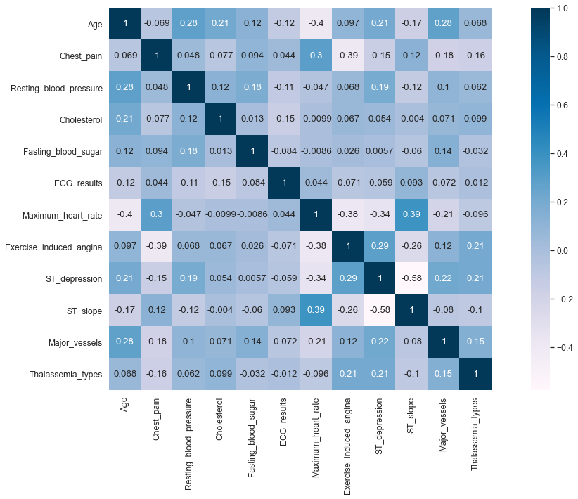

```python
plt.figure(figsize=(20,10))
cm = df.corr()
sns.set(font_scale=1.1)
sns.heatmap(cm,
            cbar=True,
            annot=True,
            square=True,
            cmap='PuBu')
```

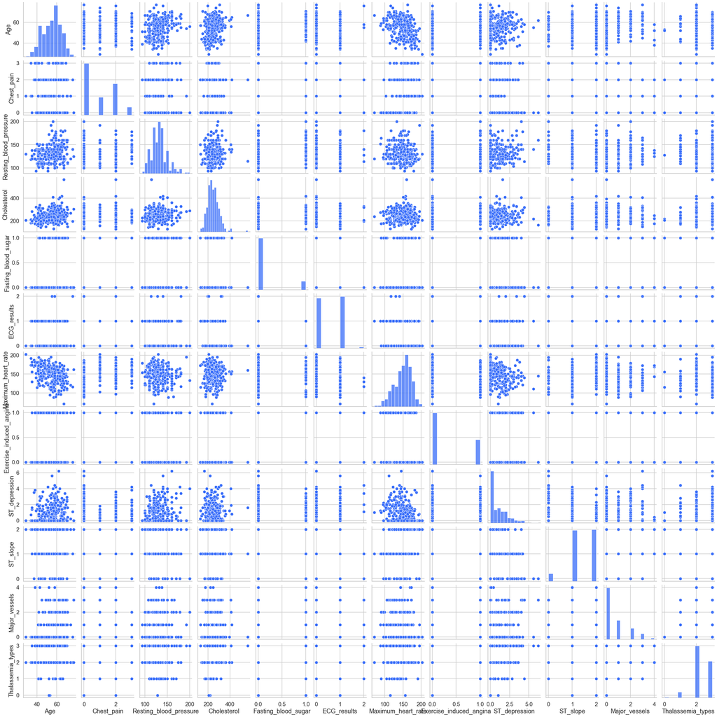

```python
# Plot
# Change defaults
sns.set_style('whitegrid')
sns.set_context('talk')
sns.set_palette('rainbow')

sns.pairplot(data=df)
```

[output not shown]

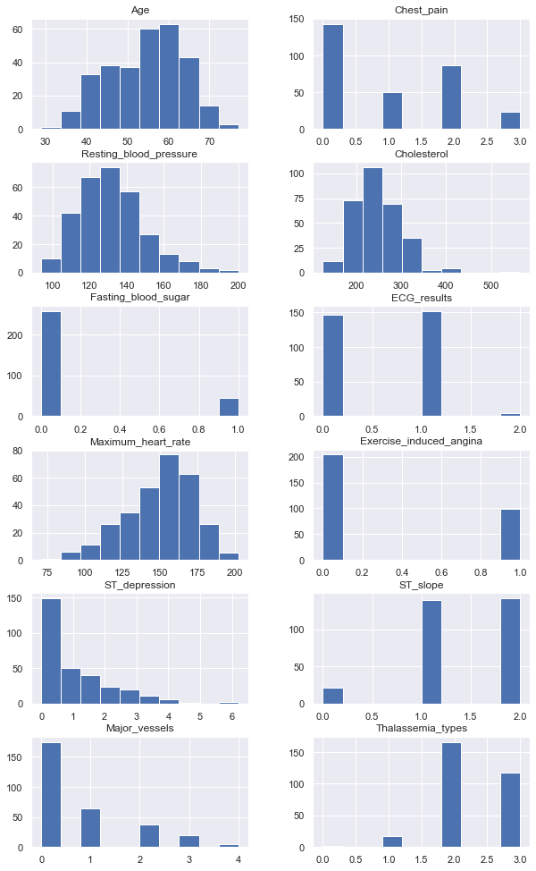

```python
sns.set(font_scale=1)
df.hist(figsize=(10,20), layout=(7,2))
```

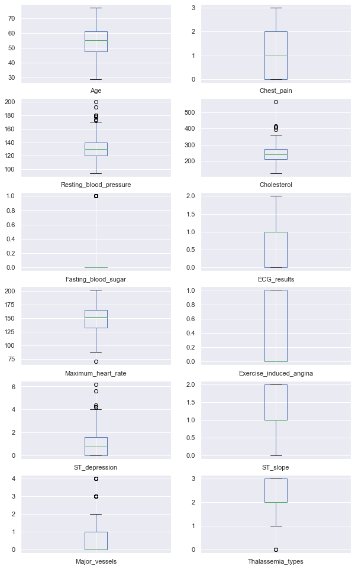

```python
# box and whiskers plot
df.plot(kind='box', subplots=True, layout=(7,2), figsize=(10,20))
plt.show()
```

We have got a lot of outliers.

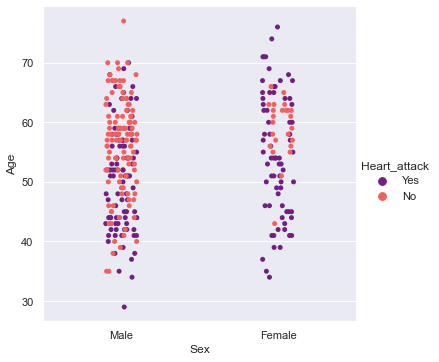

```python
sns.catplot(data=df, x='Sex', y='Age', hue='Heart_attack', palette='magma', legend=True) # target presents having or not having heart diseases
```

```python
df['Sex'].value_counts()
```

```
Male      207
Female     96
Name: Sex, dtype: int64
```

207 males and 96 females

```python
df['Heart_attack'].value_counts()
```

```
Yes    165
No     138
Name: Heart_attack, dtype: int64
```

165 cases of heart diseases

```python
df['Thalassemia_types'].value_counts()
```

```
2    166
3    117
1     18
0      2
Name: Thalassemia_types, dtype: int64
```

results of thallium stress test measuring blood flow to the heart

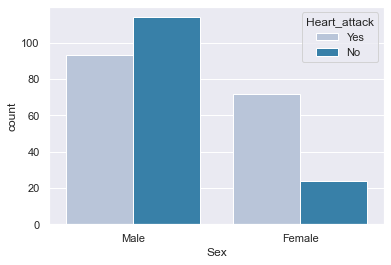

```python
sns.countplot(x='Sex', data=df, hue='Heart_attack', palette='PuBu')
```

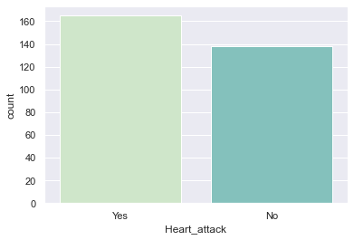

```python
 sns.countplot(x='Heart_attack', palette=sns.color_palette("GnBu", 3), data=df)  # target represents having or not having heart diseases
```

We observer that the count for not having heart disease and having heart disease are almost balanced - the amount not having disease is 140 and those having are above 160.

```python
sort_by_heart_attack = df.groupby(['Sex','Age'])['Heart_attack'].count().reset_index().sort_values(by='Heart_attack',ascending=False)
sort_by_heart_attack.head(20).style.background_gradient(cmap='Blues')
```

|  | Sex | Age | Heart_attack |
| --- | --- | --- | --- |
| 59 | Male | 58 | 13 |
| 58 | Male | 57 | 13 |
| 60 | Male | 59 | 13 |
| 53 | Male | 52 | 12 |
| 55 | Male | 54 | 11 |
| 45 | Male | 44 | 9 |
| 52 | Male | 51 | 8 |
| 57 | Male | 56 | 8 |
| 61 | Male | 60 | 7 |
| 65 | Male | 64 | 7 |
| 24 | Female | 62 | 7 |
| 43 | Male | 42 | 6 |
| 49 | Male | 48 | 6 |
| 62 | Male | 61 | 6 |
| 44 | Male | 43 | 6 |
| 68 | Male | 67 | 6 |
| 20 | Female | 58 | 6 |
| 42 | Male | 41 | 6 |
| 25 | Female | 63 | 5 |
| 54 | Male | 53 | 5 |

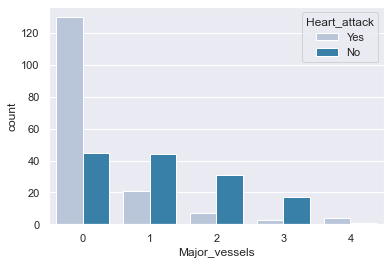

```python
sns.countplot(x='Major_vessels', hue='Heart_attack', data=df, palette='PuBu') # target presents having or not having heart diseases
```

###### ca: number of major vessels (0-3) coloured by flourosopy

```python
df['Major_vessels'].value_counts()
```

```
0    175
1     65
2     38
3     20
4      5
Name: Major_vessels, dtype: int64
```

ca number of major vessels (0-3) coloured by flourosopy ca has a negative corelation with the target i.e. when ca will increase we witness a drop in heart disease and vice versa.

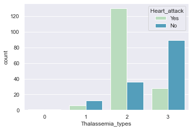

```python
sns.countplot(x='Thalassemia_types', data=df, hue='Heart_attack', palette=sns.color_palette("GnBu",2))  # target represents having or not having heart diseases
```

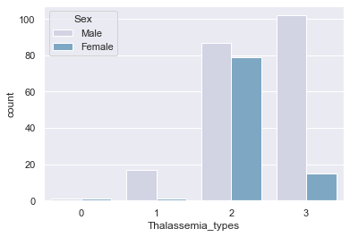

```python
sns.countplot(x='Thalassemia_types', data=df, hue='Sex', palette=sns.color_palette("PuBu", 3))
```

```python
df['Chest_pain'].value_counts() # chest pain type
```

```
0    143
2     87
1     50
3     23
Name: Chest_pain, dtype: int64
```

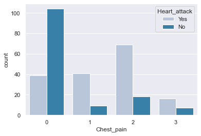

```python
sns.countplot(x='Chest_pain', hue='Heart_attack', data=df, palette='PuBu')  # target represents having or not having heart diseases
```

Shows chest pain with respet to heart disease/target

Let's find how many male and female have chest pain.

```python
sort_by_chest_pain = df.groupby(['Sex','Chest_pain'])['Heart_attack'].count().reset_index().sort_values(by='Heart_attack',ascending=False)
sort_by_chest_pain.head(10).style.background_gradient(cmap='PuBu')
```

|  | Sex | Chest_pain | Heart_attack |
| --- | --- | --- | --- |
| 4 | Male | 0 | 104 |
| 6 | Male | 2 | 52 |
| 0 | Female | 0 | 39 |
| 2 | Female | 2 | 35 |
| 5 | Male | 1 | 32 |
| 7 | Male | 3 | 19 |
| 1 | Female | 1 | 18 |
| 3 | Female | 3 | 4 |

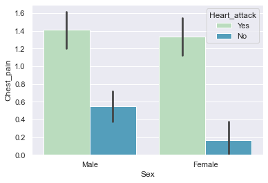

```python
sns.barplot(x='Sex', y='Chest_pain', hue='Heart_attack', data=df, palette=sns.color_palette("GnBu", 2))  # target represents having or not having heart diseases
```

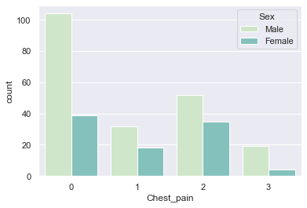

```python
sns.countplot(x='Chest_pain', hue='Sex', data=df, palette=sns.color_palette("GnBu", 3))
```

This shows chest pain count experienced by male and female.

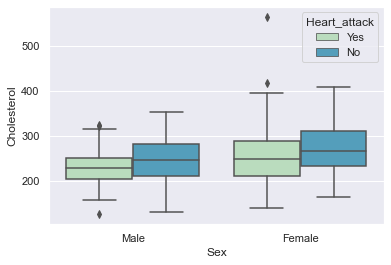

```python
sns.boxplot(x='Sex', y='Cholesterol', data=df, hue='Heart_attack', palette=sns.color_palette("GnBu", 2)) # target presents having or not having heart diseases
```

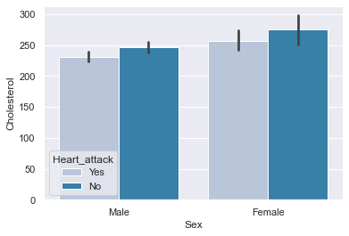

```python
sns.barplot(data=df, x='Sex', y='Cholesterol', hue='Heart_attack', palette='PuBu') # target presents having or not having heart diseases
```

```python
sort_by_cholesterol = df.groupby(['Sex','Cholesterol'])['Heart_attack'].count().reset_index().sort_values(by='Heart_attack',ascending=False)
sort_by_cholesterol.head(10).style.background_gradient(cmap='Blues')
```

|  | Sex | Cholesterol | Heart_attack |
| --- | --- | --- | --- |
| 115 | Male | 212 | 5 |
| 109 | Male | 204 | 4 |
| 135 | Male | 234 | 4 |
| 134 | Male | 233 | 4 |
| 172 | Male | 282 | 4 |
| 150 | Male | 254 | 4 |
| 48 | Female | 269 | 4 |
| 144 | Male | 246 | 3 |
| 143 | Male | 245 | 3 |
| 141 | Male | 243 | 3 |

We observe the outliers with the help of boxplot, outliers are values that are very small or large inthe given data set.

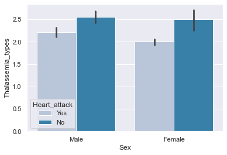

```python
sns.barplot(x='Sex', y='Thalassemia_types', data=df, hue='Heart_attack', palette='PuBu')
```

```python
sort_by_thalassemia_types = df.groupby(['Sex','Thalassemia_types'])['Heart_attack'].count().reset_index().sort_values(by='Heart_attack',ascending=False)
sort_by_thalassemia_types.head(10).style.background_gradient(cmap='Blues')
```

|  | Sex | Thalassemia_types | Heart_attack |
| --- | --- | --- | --- |
| 7 | Male | 3 | 102 |
| 6 | Male | 2 | 87 |
| 2 | Female | 2 | 79 |
| 5 | Male | 1 | 17 |
| 3 | Female | 3 | 15 |
| 0 | Female | 0 | 1 |
| 1 | Female | 1 | 1 |
| 4 | Male | 0 | 1 |

Here I have experimented with thal and observed with the number of major vessels 'ca'

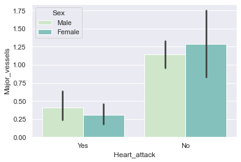

```python
sns.barplot(x='Heart_attack', y='Major_vessels', hue='Sex', data=df, palette=sns.color_palette("GnBu", 3))
```

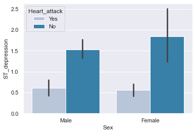

```python
sns.barplot(x='Sex', y='ST_depression', data=df, hue='Heart_attack', palette='PuBu')
```

```python
sort_by_st_depression = df.groupby(['Sex','ST_depression'])['Heart_attack'].count().reset_index().sort_values(by='Heart_attack',ascending=False)
sort_by_st_depression.head(10).style.background_gradient(cmap='Blues')
```

|  | Sex | ST_depression | Heart_attack |
| --- | --- | --- | --- |
| 27 | Male | 0.000000 | 64 |
| 0 | Female | 0.000000 | 35 |
| 37 | Male | 1.200000 | 13 |
| 34 | Male | 0.800000 | 10 |
| 36 | Male | 1.000000 | 9 |
| 41 | Male | 1.800000 | 8 |
| 38 | Male | 1.400000 | 8 |
| 33 | Male | 0.600000 | 8 |
| 43 | Male | 2.000000 | 7 |
| 40 | Male | 1.600000 | 7 |

The lower the depression, the higher the cases were for heart attack.

###### oldpeak = ST depression induced by exercise relative to rest, measures of abnormality in electrocardiograms

```python
df['Fasting_blood_sugar'].value_counts()
```

```
0    258
1     45
Name: Fasting_blood_sugar, dtype: int64
```

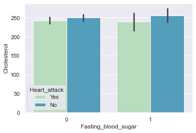

```python
sns.barplot(x='Fasting_blood_sugar', y='Cholesterol', data=df, hue='Heart_attack', palette=sns.color_palette("GnBu", 2))  # target represents having or not having heart diseases
```

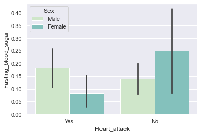

```python
sns.barplot(x='Heart_attack', y='Fasting_blood_sugar', data=df, hue='Sex', palette=sns.color_palette("GnBu", 3))
```

```python
sort_by_fasting_blood_sugar = df.groupby(['Sex','Fasting_blood_sugar'])['Heart_attack'].count().reset_index().sort_values(by='Heart_attack',ascending=False)
sort_by_fasting_blood_sugar.head(10).style.background_gradient(cmap='GnBu')
```

|  | Sex | Fasting_blood_sugar | Heart_attack |
| --- | --- | --- | --- |
| 2 | Male | 0 | 174 |
| 0 | Female | 0 | 84 |
| 3 | Male | 1 | 33 |
| 1 | Female | 1 | 12 |

This shows relation of Fasting blood sugar with heart attack in case of Male and Females.

#### Cross tables

```python
tb_heart_disease = pd.crosstab(df['Sex'], df['Heart_attack'])
tb_heart_disease
```

| Heart_attack Sex | No | Yes |
| --- | --- | --- |
| Female | 24 | 72 |
| Male | 114 | 93 |

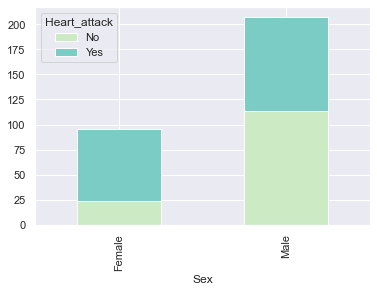

```python
# tb_heart_disease.plot(kind='bar', stacked=True, color=['lightblue', 'teal'], grid=True)
tb_heart_disease.plot(kind='bar', stacked=True, color=sns.color_palette("GnBu", 3), grid=True)
```

```python
tb_thal = pd.crosstab(index=df['Heart_attack'], columns=[df['Thalassemia_types']], margins=True)
tb_thal
```

| Thalassemia_types Heart_attack | 0 | 1 | 2 | 3 | All |
| --- | --- | --- | --- | --- | --- |
| No | 1 | 12 | 36 | 89 | 138 |
| Yes | 1 | 6 | 130 | 28 | 165 |
| All | 2 | 18 | 166 | 117 | 303 |

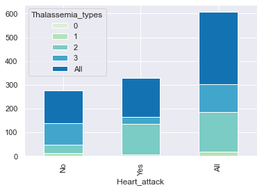

```python
tb_thal.plot(kind='bar', stacked=True, color=sns.color_palette("GnBu", 5))
plt.show()
```

```python
tb_chest_pain = pd.crosstab(df['Chest_pain'], df['Heart_attack'])
tb_chest_pain
```

| Heart_attack Chest_pain | No | Yes |
| --- | --- | --- |
| 0 | 104 | 39 |
| 1 | 9 | 41 |
| 2 | 18 | 69 |
| 3 | 7 | 16 |

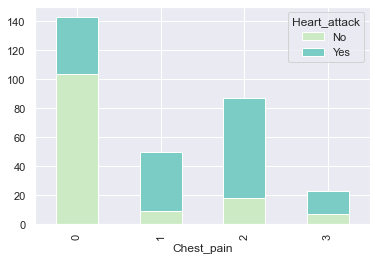

```python
tb_chest_pain.plot(kind='bar', stacked=True, color=sns.color_palette("GnBu", 3), grid=True) # target represents having or not having heart diseases
```

### Bivariate Analysis

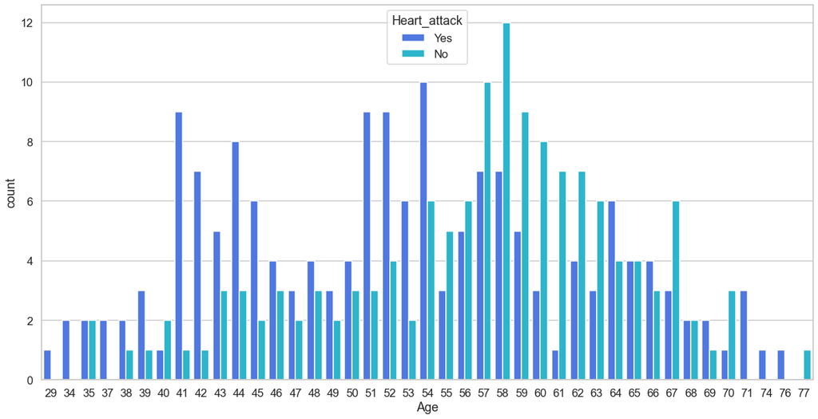

```python
# Change defaults
sns.set_style('whitegrid')
sns.set_context('talk')
sns.set_palette('rainbow')

plt.figure(figsize=(20, 10)) # change the size of the plot
sns.countplot(x = 'Age',hue = 'Heart_attack', data = df)
```

The dependence of Heart Attack on Age.

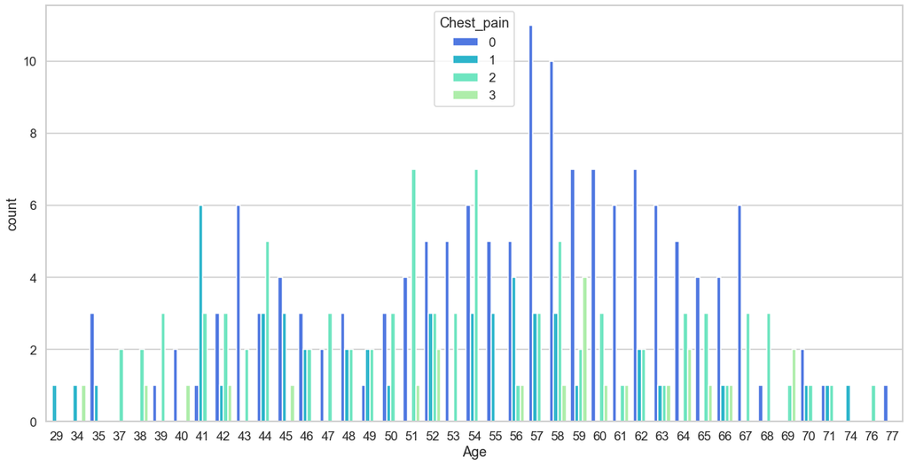

```python
plt.figure(figsize=(20, 10)) # change the size of the plot
sns.countplot(x = 'Age',hue = 'Chest_pain', data = df)
```

The dependence of Chest pain on Age.

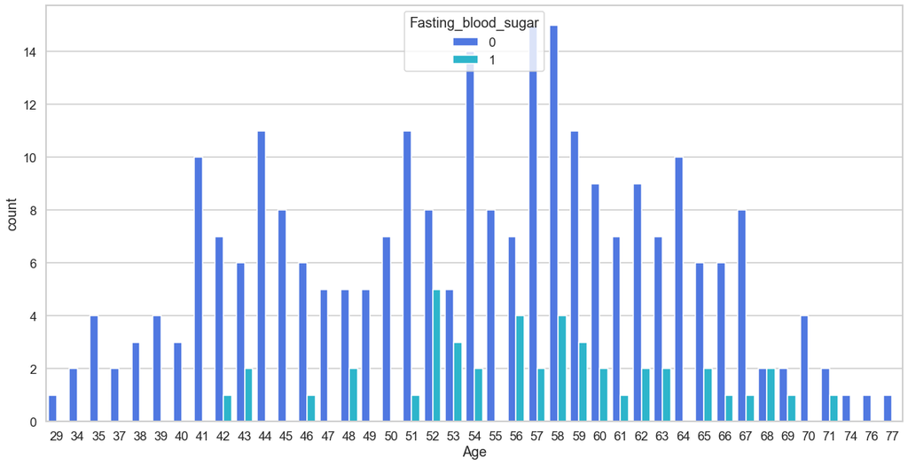

```python
plt.figure(figsize=(20, 10)) # change the size of the plot
sns.countplot(x = 'Age',hue = 'Fasting_blood_sugar', data = df)
```

The dependence of result of Fasting blood sugar on age.

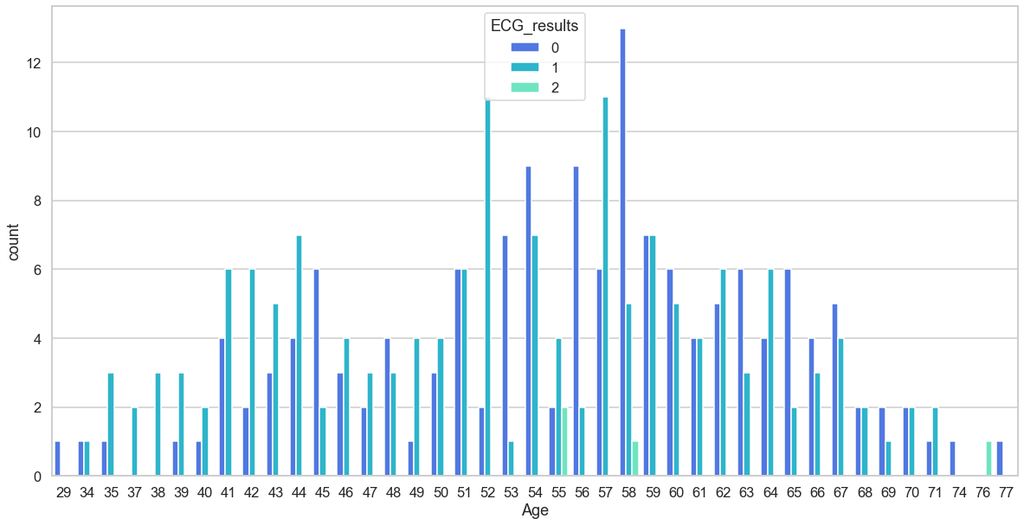

```python
plt.figure(figsize=(20, 10)) # change the size of the plot
sns.countplot(x = 'Age',hue = 'ECG_results', data = df)
```

The dependence of result of ECG on age.

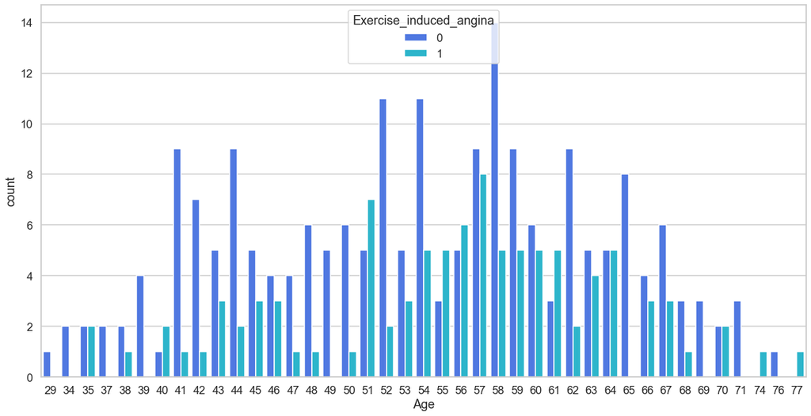

```python
plt.figure(figsize=(20, 10)) # change the size of the plot
sns.countplot(x = 'Age',hue = 'Exercise_induced_angina', data = df)
```

The dependence of result of Exercise Induced Angina on age.